# Exploratory Data Analysis for PROJECT

Introduction: I am interested in exploring in understanding the results of the City of Seattle’s participatory budgeting initiative, “Your Voice, Your Choice”. In particular, I am interested if there are any common themes among the projects that were ultimately selected for funding. The variable of interest is “Project Status”. I will also explore “Average Score”, “Project Type”, and “Neighborhood”.

1. Retrieve data from GitHub repo:

```r
library(RCurl)
data <-
read.csv(text=getURL("https://raw.githubusercontent.com/katrinae-uw/data/master/Your_Voice_Your_Choice_Master_List_of_All_Projects_With_Scores.csv"))
```

```r
is.data.frame(data)
```

```
## [1] TRUE
```

My variable of interest is reading as a factor variable with levels.

```r
str(data)
```

```
## 'data.frame':    874 obs. of  17 variables:
##  $ Project.Status      : Factor w/ 6 levels "Already Funded",..: 5 5 3 5 3 5 3 5 4 4 ...
##  $ X1st.Review         : num  18 20 16 15 20 14 17 18 16 0 ...
##  $ X2nd.Review         : num  16 20 16 18 17 18 17 20 19 19 ...
##  $ Average.Score       : Factor w/ 57 levels "","0","1","10",..: 24 33 22 23 27 22 24 28 25 49 ...
##  $ Initial.Review.Notes: Factor w/ 152 levels "","71st ST overpass (SDOT) taken care of in budget",..: 1 1 1 1 1 1 1 1 1 1 ...
##  $ Project..           : Factor w/ 866 levels "17-001","17-002",..: 6 14 17 28 39 59 74 223 131 132 ...
##  $ Project.Combined    : Factor w/ 30 levels "","With 17-011",..: 1 1 1 1 1 1 1 1 1 10 ...
##  $ Project.Title       : Factor w/ 752 levels "4-way stop at McGraw & 7th Ave W",..: 739 257 104 153 344 182 67 748 426 282 ...
##  $ Need.               : Factor w/ 849 levels "  The people that live in highpoint take this road to take their kids to school and get to work and most famili"| __truncated__,..: 776 24 566 266 505 512 758 639 606 300 ...
##  $ Idea.               : Factor w/ 812 levels "","\tA traffic calming mechanism is much at the intersection of 14th Ave S & Dallas Ave S. This is a VERY dangerou"| __truncated__,..: 347 660 782 41 226 44 119 788 204 43 ...
##  $ Coordinates         : Factor w/ 676 levels ""," 47.649275, -122.304303",..: 10 13 18 26 48 178 86 121 201 202 ...
##  $ Location.           : Factor w/ 775 levels ""," from South Charlestown street down Rainer ave South down to South Genesee street i",..: 606 294 186 373 625 700 632 142 709 114 ...
##  $ Project.Type        : Factor w/ 14 levels "","Accessibility Improvements",..: 14 3 7 3 3 3 1 14 3 3 ...
##  $ Dept.               : Factor w/ 8 levels "King County",..: 3 5 5 5 5 5 5 5 5 5 ...
##  $ Who.Benefits.       : Factor w/ 790 levels "","  drivers and resdients   ",..: 413 723 276 455 696 198 543 577 492 683 ...
##  $ Council.District.   : int  1 1 1 1 1 1 1 2 1 1 ...
##  $ Neighborhood        : Factor w/ 160 levels "","Admiral","Alaska Junction",..: 128 131 128 65 131 148 63 57 148 49 ...
```

I’m curious what to the see the frequency for each of the values of “Project Status”.

```r
prop.table(table(data$Project.Status))
```

```
##
##                 Already Funded                Did Not Advance
##                     0.05720824                     0.57437071
## Funded for 2018 Implementation                   Not Feasible
##                     0.05377574                     0.25629291
##          On Ballot, Not Funded        Referred to Maintenance
##                     0.04004577                     0.01830664
```

Verifying the mode

```r
distribution=table(data$Project.Status)
modeCount=max(distribution)
mode=distribution[distribution==modeCount]
names(mode)
```

```
## [1] "Did Not Advance"
```

Creating the getMode function

```r
getMode=function(aColumn){
  freqTable=table(aColumn)
  maxFrequency=max(freqTable)
  names(freqTable[freqTable==maxFrequency])
}
```

Setting the variable and confirming the mode with the new getMode function

```r
var=data$Project.Status
getMode(var)
```

```
## [1] "Did Not Advance"
```

Plotting the variable

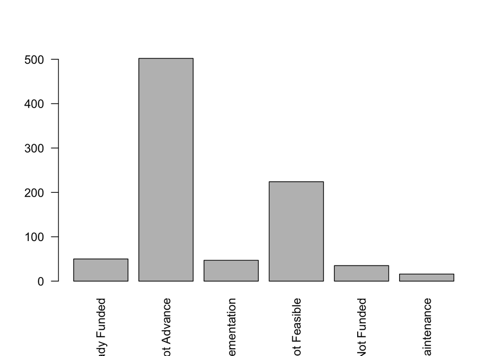

```r
barplot(table(var),las=2)
```

I’m also curious about “Average Score”, which is a numerical measure variable, but when I check I see it is being read as a factor with levels.

```r
str(data)
```

```
## 'data.frame':    874 obs. of  17 variables:
##  $ Project.Status      : Factor w/ 6 levels "Already Funded",..: 5 5 3 5 3 5 3 5 4 4 ...
##  $ X1st.Review         : num  18 20 16 15 20 14 17 18 16 0 ...
##  $ X2nd.Review         : num  16 20 16 18 17 18 17 20 19 19 ...
##  $ Average.Score       : Factor w/ 57 levels "","0","1","10",..: 24 33 22 23 27 22 24 28 25 49 ...
##  $ Initial.Review.Notes: Factor w/ 152 levels "","71st ST overpass (SDOT) taken care of in budget",..: 1 1 1 1 1 1 1 1 1 1 ...
##  $ Project..           : Factor w/ 866 levels "17-001","17-002",..: 6 14 17 28 39 59 74 223 131 132 ...
##  $ Project.Combined    : Factor w/ 30 levels "","With 17-011",..: 1 1 1 1 1 1 1 1 1 10 ...
##  $ Project.Title       : Factor w/ 752 levels "4-way stop at McGraw & 7th Ave W",..: 739 257 104 153 344 182 67 748 426 282 ...
##  $ Need.               : Factor w/ 849 levels "  The people that live in highpoint take this road to take their kids to school and get to work and most famili"| __truncated__,..: 776 24 566 266 505 512 758 639 606 300 ...
##  $ Idea.               : Factor w/ 812 levels "","\tA traffic calming mechanism is much at the intersection of 14th Ave S & Dallas Ave S. This is a VERY dangerou"| __truncated__,..: 347 660 782 41 226 44 119 788 204 43 ...
##  $ Coordinates         : Factor w/ 676 levels ""," 47.649275, -122.304303",..: 10 13 18 26 48 178 86 121 201 202 ...
##  $ Location.           : Factor w/ 775 levels ""," from South Charlestown street down Rainer ave South down to South Genesee street i",..: 606 294 186 373 625 700 632 142 709 114 ...
##  $ Project.Type        : Factor w/ 14 levels "","Accessibility Improvements",..: 14 3 7 3 3 3 1 14 3 3 ...
##  $ Dept.               : Factor w/ 8 levels "King County",..: 3 5 5 5 5 5 5 5 5 5 ...
##  $ Who.Benefits.       : Factor w/ 790 levels "","  drivers and resdients   ",..: 413 723 276 455 696 198 543 577 492 683 ...
##  $ Council.District.   : int  1 1 1 1 1 1 1 2 1 1 ...
##  $ Neighborhood        : Factor w/ 160 levels "","Admiral","Alaska Junction",..: 128 131 128 65 131 148 63 57 148 49 ...
```

There must be some non number values for some observations. So, I need to make a new column forcing all values to be numeric, but because the factors were with levels I need to first force it into characters. So, I need to remember to first read my data to be read as stringsasFractos=FALSE. I called this column “Average.Numeric”. I saw that this new column included the value “NA”. Then I created a subset of my data and called it data.sub, to include all values when NA is FALSE.

```r
head(data)
```

|  | Project.Status | X1st.Review | X2nd.Review | Average.Score | Initial.Review.Notes | Project.. | Project.Combined | Project.Title | Need. | Idea. | Coordinates | Location. | Project.Type | Dept. | Who.Benefits. | Council.District. | Neighborhood |
| --- | --- | --- | --- | --- | --- | --- | --- | --- | --- | --- | --- | --- | --- | --- | --- | --- | --- |
| 1 | On Ballot, Not Funded | 18 | 16 | 17 |  | 17-006 |  | Trail improvements @ Roxhill Park | Trail improvements at Roxhill Park - violence and danger in park, drug use, public intoxication | Improve lighting and trim trees around trails .. Interpretive trail improvements | 47.51775, -122.36925 | Roxhill Park | Walkways | Parks | neighbors, Westwood Village, and city of Seattle | 1 | South Delridge |
| 2 | On Ballot, Not Funded | 20 | 20 | 20 |  | 17-014 |  | Improve 5-way intersection @ Dallas Ave S, 12th Ave S, and Thistle St | A traffic calming mechanism is much needed at a FIVE WAY intersection with no lights or stop signs at Dallas Ave S, 12th Ave S, and S Thistle St. There is a large business with over 100 employees & ca… | Simple all-way stop signs; adding stop signs or yield signs. Perhaps even a roundabout. Adding crosswalks (with flashing lights) to multiple corners since it's an odd intersection. Adding a dedicated … | 47.519390, -122.315010 | Dallas Ave S, 12th Ave S, S Thistle St | Crossing Improvements | SDOT | The neighbors who live at this intersection (some feel they are in danger of having a car come through their window), the neighbors who use Dallas Ave as a thoroughfare to enter and exit South Park's … | 1 | South Park |
| 3 | Funded for 2018 Implementation | 16 | 16 | 16 |  | 17-019 |  | Busstop improvements on Barton St | The "Delridge Bus Triangle" located at 9200 Delridge Way, is an SDOT managed property in the heart of the Westwood Highland Park Residential Urban Village. This public right of way is fraught with hid… | We have already created a "Friends of the Delridge Bus Triangle" committee, in partnership with SDOT. We held our first meeting on Jan 28th, 2017 to document the history, needs and collective vision o… | 47.520934, -122.358290 | 9200 Delridge Way SW, cross streets are Barton STREET SW to the north, and 18th Ave SW to the east. | Other | SDOT | Everyone living in along the South Delridge Corridor, with particular benefit to the marginalized, at-risk children that live in the densely populated area immediately east of this space. | 1 | South Delridge |
| 4 | On Ballot, Not Funded | 15 | 18 | 16.5 |  | 17-031 |  | Crossing Improvement along SW Henderson St | Improve crossings along SW Henderson St at 12th, 13th, or 17th Ave SW | A clearly marked cross walk and parking restrictions near the curb would be a start to helping to increase visibility for cars as well as pedestrians. Extending the curbs, however, would make a huge d… | 47.522840, -122.351640 | Henderson & 13th Ave SW 98106 | Crossing Improvements | SDOT | Pedestrians and drivers alike. The neighborhood benefits by an increase in safety and walkability. | 1 | Highland Park |
| 5 | Funded for 2018 Implementation | 20 | 17 | 18.5 |  | 17-044 |  | Improved crossings on S. Cloverdale | S Cloverdale St is a busy road and 12th Ave S was identified in South Park's Open Space plan as a secondary improved walking/bike route. We would like to increase the safety for pedestrians to cross C… | Crosswalks on S. Cloverdale at 8th Ave S, 10th Ave S. and/or 12th Ave S. for pedestrians to cross safely with a high vis sign alerting drivers to the possibility of pedestrians; Speed bumps, crosswalk… | 47.526450, -122.320230 | S. Cloverdale at 10th Ave S and 12th Ave S. Skate Park, South Park Meadow Dallas and 12th Ave S, Cloverdale and 5th Ave s. | Crossing Improvements | SDOT | The entire neighborhood | 1 | South Park |
| 6 | On Ballot, Not Funded | 14 | 18 | 16 |  | 17-068 |  | Crossing improvements at 35th Ave & SW Dawson St | Safer ped crossing @ 35th Ave SW to Camp Long, near SW Dawson St | A crosswalk at the intersection of 35th Ave SW and SW Dawson Street (the entrance to Camp Long), including an island in the median. | 47.555598, -122.376317 | The intersection between 35th Ave SW and SW Dawson Street in West Seattle | Crossing Improvements | SDOT | Children, community members and nature-lovers who use Camp Long and live in the surrounding area. | 1 | West Seattle |

```r
class(data$Average.Score)
```

```
## [1] "factor"
```

```r
?is.numeric
is.numeric(data$Average.Score)
```

```
## [1] FALSE
```

```r
as.numeric(data$Average.Score)
```

```
##   [1] 24 33 22 23 27 22 24 28 25 49 43 24 15 23 22 19 22 20 17 19 22 14 19
##  [24] 27 33 25 23 25 19 19 22 19 17 17 27 27 20 19 22 16 17 18 26 17 19 53
##  [47] 19 23 24 22 19 17 14 29 24 23 13 13 24 17 13 19 19 26 23 22 26 26 23
##  [70] 13 19 22 22  5  5  9 23 22 22 22 22 14 22 22 33 25 51 40 22 19 19 22
##  [93] 19 19 19 19 19 19 19 19 19 19 19 19 19 19 19 19 27 19 17  1 51 50 51
## [116]  1  1 51  1 51  1 51  1  1  5  4 26 39 22 30 30 44 44 54 44 43 43 43
## [139] 43 47 15 33 25 14 13 13 39  4  4  4  4  4  9 46 46 23 23 24  7 40 40
## [162] 46 40 28 47 27 24 24 46 14 20 11 33 33  5 33 49 31 40 36 17 17 37 23
## [185] 26 42 26 17 42 44 46  7  5 44 15 37  7  7 24 11 22 22  6 42  6 46 25
## [208] 47 26  4 14 42 42 22 42 30 42 49 26  2 22  6 13 36  2 47  6  4 34 34
## [231] 42 53 38 41  6  6  6  4 40 37 53 35 44 14 43 17 47 47 15  4 28 46 49
## [254] 13 41  5 42 42  3 13 32 22 40 20 27 38 44 17 22 15 48 43 17 37 27  4
## [277] 19 11 49  9 23  4 13 42  6 24 17 49 41  9 25  9  9 23 22 17 22  5 47
## [300]  6 23 13 41  9 47  4 17  4  5  6 23 17  9  9  9 17 17 41 40 47 39  5
## [323] 41 42 42 46 47  9 47 41 41 40 40 40 39 40  6 19 42 42  9 34 43  5 13
```

[output cut: 23 more lines]

```r
data$Average.Numeric=as.numeric(as.character(data$Average.Score))
data$Average.Numeric
```

```
##   [1] 17.00 20.00 16.00 16.50 18.50 16.00 17.00 19.00 17.50  9.50  7.50
##  [12] 17.00 14.00 16.50 16.00 15.00 16.00 15.50 14.50 15.00 16.00 13.50
##  [23] 15.00 18.50 20.00 17.50 16.50 17.50 15.00 15.00 16.00 15.00 14.50
##  [34] 14.50 18.50 18.50 15.50 15.00 16.00 14.25 14.50 14.75 18.00 14.50
##  [45] 15.00    NA 15.00 16.50 17.00 16.00 15.00 14.50 13.50 19.50 17.00
##  [56] 16.50 13.00 13.00 17.00 14.50 13.00 15.00 15.00 18.00 16.50 16.00
##  [67] 18.00 18.00 16.50 13.00 15.00 16.00 16.00 10.50 10.50 12.00 16.50
##  [78] 16.00 16.00 16.00 16.00 13.50 16.00 16.00 20.00 17.50    NA  6.00
##  [89] 16.00 15.00 15.00 16.00 15.00 15.00 15.00 15.00 15.00 15.00 15.00
## [100] 15.00 15.00 15.00 15.00 15.00 15.00 15.00 15.00 15.00 18.50 15.00
## [111] 14.50    NA    NA    NA    NA    NA    NA    NA    NA    NA    NA
## [122]    NA    NA    NA 10.50 10.00 18.00  5.50 16.00  2.00  2.00  8.00
## [133]  8.00    NA  8.00  7.50  7.50  7.50  7.50  9.00 14.00 20.00 17.50
## [144] 13.50 13.00 13.00  5.50 10.00 10.00 10.00 10.00 10.00 12.00  8.50
## [155]  8.50 16.50 16.50 17.00 11.50  6.00  6.00  8.50  6.00 19.00  9.00
```

[output cut: 65 more lines]

```r
data.sub=data[is.na(data$Average.Numeric) == FALSE,]
data.sub$Average.Numeric
```

```
##   [1] 17.00 20.00 16.00 16.50 18.50 16.00 17.00 19.00 17.50  9.50  7.50
##  [12] 17.00 14.00 16.50 16.00 15.00 16.00 15.50 14.50 15.00 16.00 13.50
##  [23] 15.00 18.50 20.00 17.50 16.50 17.50 15.00 15.00 16.00 15.00 14.50
##  [34] 14.50 18.50 18.50 15.50 15.00 16.00 14.25 14.50 14.75 18.00 14.50
##  [45] 15.00 15.00 16.50 17.00 16.00 15.00 14.50 13.50 19.50 17.00 16.50
##  [56] 13.00 13.00 17.00 14.50 13.00 15.00 15.00 18.00 16.50 16.00 18.00
##  [67] 18.00 16.50 13.00 15.00 16.00 16.00 10.50 10.50 12.00 16.50 16.00
##  [78] 16.00 16.00 16.00 13.50 16.00 16.00 20.00 17.50  6.00 16.00 15.00
##  [89] 15.00 16.00 15.00 15.00 15.00 15.00 15.00 15.00 15.00 15.00 15.00
## [100] 15.00 15.00 15.00 15.00 15.00 15.00 15.00 18.50 15.00 14.50 10.50
## [111] 10.00 18.00  5.50 16.00  2.00  2.00  8.00  8.00  8.00  7.50  7.50
## [122]  7.50  7.50  9.00 14.00 20.00 17.50 13.50 13.00 13.00  5.50 10.00
## [133] 10.00 10.00 10.00 10.00 12.00  8.50  8.50 16.50 16.50 17.00 11.50
## [144]  6.00  6.00  8.50  6.00 19.00  9.00 18.50 17.00 17.00  8.50 13.50
## [155] 15.50 12.50 20.00 20.00 10.50 20.00  9.50  2.50  6.00  4.00 14.50
```

[output cut: 44 more lines]

Now, I can explore my data.

```r
summary(data.sub$Average.Numeric)
```

```
##    Min. 1st Qu.  Median    Mean 3rd Qu.    Max.
##    0.00    8.00   12.00   11.48   15.00   20.00
```

The mean and median are fairly close, so I wonder what my distribution looks like.

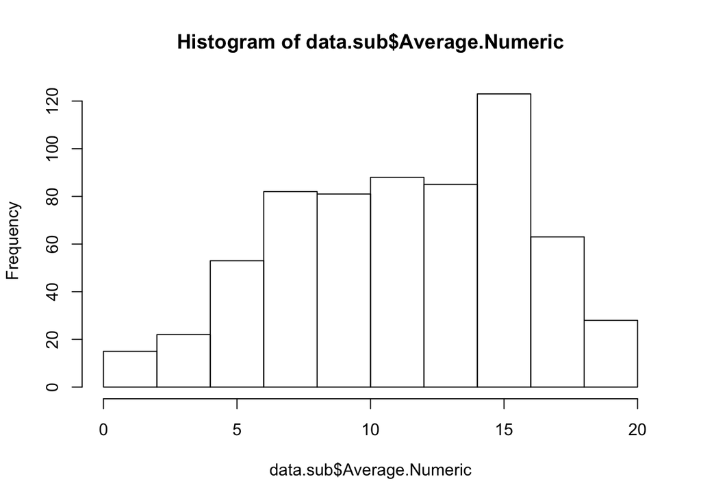

```r
hist(data.sub$Average.Numeric)
```

It doesn’t quite look normal, so I’ll look at the skewness.

```r
library(moments)
skewness(data.sub$Average.Numeric)
```

```
## [1] -0.2871413
```

I’m curious to see the relationship between Project Status and Average Scores.

```r
prop.table(table(data.sub$Project.Status,data.sub$Average.Numeric))
```

```
##
##                                          0         1         2       2.5
##   Already Funded                 0.0000000 0.0000000 0.0031250 0.0000000
##   Did Not Advance                0.0046875 0.0046875 0.0093750 0.0031250
##   Funded for 2018 Implementation 0.0000000 0.0000000 0.0000000 0.0000000
##   Not Feasible                   0.0015625 0.0000000 0.0000000 0.0000000
##   On Ballot, Not Funded          0.0000000 0.0000000 0.0000000 0.0000000
##   Referred to Maintenance        0.0000000 0.0000000 0.0000000 0.0000000
##
##                                       2.75         3       3.5         4
##   Already Funded                 0.0000000 0.0000000 0.0000000 0.0000000
##   Did Not Advance                0.0015625 0.0078125 0.0078125 0.0125000
##   Funded for 2018 Implementation 0.0000000 0.0000000 0.0000000 0.0000000
##   Not Feasible                   0.0000000 0.0000000 0.0000000 0.0000000
##   On Ballot, Not Funded          0.0000000 0.0000000 0.0000000 0.0000000
##   Referred to Maintenance        0.0000000 0.0015625 0.0000000 0.0000000
##
##                                        4.5         5       5.5         6
##   Already Funded                 0.0000000 0.0000000 0.0015625 0.0015625
##   Did Not Advance                0.0109375 0.0187500 0.0093750 0.0406250
##   Funded for 2018 Implementation 0.0000000 0.0000000 0.0000000 0.0000000
##   Not Feasible                   0.0000000 0.0000000 0.0000000 0.0000000
##   On Ballot, Not Funded          0.0000000 0.0000000 0.0000000 0.0000000
##   Referred to Maintenance        0.0000000 0.0000000 0.0000000 0.0000000
##
##                                        6.5         7       7.5         8
##   Already Funded                 0.0000000 0.0000000 0.0000000 0.0031250
##   Did Not Advance                0.0187500 0.0484375 0.0218750 0.0343750
##   Funded for 2018 Implementation 0.0000000 0.0000000 0.0000000 0.0000000
##   Not Feasible                   0.0000000 0.0000000 0.0015625 0.0000000
##   On Ballot, Not Funded          0.0000000 0.0000000 0.0000000 0.0000000
##   Referred to Maintenance        0.0000000 0.0000000 0.0000000 0.0000000
##
##                                       8.25       8.5         9      9.25
##   Already Funded                 0.0000000 0.0000000 0.0000000 0.0000000
##   Did Not Advance                0.0015625 0.0203125 0.0281250 0.0015625
##   Funded for 2018 Implementation 0.0000000 0.0000000 0.0000000 0.0000000
##   Not Feasible                   0.0000000 0.0000000 0.0000000 0.0000000
##   On Ballot, Not Funded          0.0000000 0.0000000 0.0000000 0.0000000
##   Referred to Maintenance        0.0000000 0.0000000 0.0000000 0.0000000
```

[output cut: 41 more lines]

```
##                                       16.5        17      17.5        18
##   Already Funded                 0.0015625 0.0000000 0.0000000 0.0015625
##   Did Not Advance                0.0218750 0.0109375 0.0046875 0.0140625
##   Funded for 2018 Implementation 0.0046875 0.0078125 0.0015625 0.0046875
##   Not Feasible                   0.0062500 0.0015625 0.0015625 0.0015625
##   On Ballot, Not Funded          0.0046875 0.0046875 0.0046875 0.0000000
##   Referred to Maintenance        0.0000000 0.0000000 0.0000000 0.0000000
##
##                                       18.5        19      19.5        20
##   Already Funded                 0.0015625 0.0000000 0.0000000 0.0000000
##   Did Not Advance                0.0156250 0.0046875 0.0000000 0.0062500
##   Funded for 2018 Implementation 0.0015625 0.0000000 0.0000000 0.0015625
##   Not Feasible                   0.0046875 0.0000000 0.0000000 0.0000000
##   On Ballot, Not Funded          0.0015625 0.0015625 0.0015625 0.0031250
##   Referred to Maintenance        0.0000000 0.0000000 0.0000000 0.0000000
```

```r
aggregate(data.sub$Average.Numeric,list(data.sub$Project.Status),median)
```

| Group.1 | x |
| --- | --- |
| Already Funded | 15.0 |
| Did Not Advance | 10.5 |
| Funded for 2018 Implementation | 16.0 |
| Not Feasible | 16.0 |
| On Ballot, Not Funded | 16.0 |
| Referred to Maintenance | 3.0 |

This is interesting because the median for “On Ballot, Not Funded” is the same as for “Funded for 2018 Implementation”. So, voters aren’t necessarily voting for projects with the highest scores, as assigned by the committee.

I’m also curious about the variable “Neighborhood”. This is a categorical, polytomous non-ordinal variable. I want to see the distribution of projects proposed by neighborhood.

```r
prop.table(table(data$Neighborhood))
```

```
##
##
##                                                                                                                                                    0.019450801
##                                                                                                                                                        Admiral
##                                                                                                                                                    0.011441648
##                                                                                                                                                Alaska Junction
##                                                                                                                                                    0.001144165
##                                                                                                                                                           Alki
##                                                                                                                                                    0.004576659
##                                                                                                                                                            All
##                                                                                                                                                    0.001144165
##                                                                                                                                                  Arbor Heights
##                                                                                                                                                    0.003432494
##                                                                                                                                                 Arbor Heights
##                                                                                                                                                    0.001144165
##                                                                                                                                                        Ballard
##                                                                                                                                                    0.030892449
##                                                                                                                                                       Ballard
##                                                                                                                                                    0.001144165
##                                                                                                                                     Ballard/Fremont/U-distric
##                                                                                                                                                    0.001144165
##                                                                                                                                                    Beacon Hill
##                                                                                                                                                    0.017162471
##                                                                                                                                                   Beacon HIll
##                                                                                                                                                    0.001144165
##                                                                                                                                    Beacon Hill, Rainier Valley
```

[output cut: 295 more lines]

There are many neighborhoods, so it is hard to confirm the mode by eye. Confirming the mode with the getMode function.

```r
var=data$Neighborhood
getMode(var)
```

```
## [1] "Capitol Hill"
```

I also noticed in the frequency table that inconsistent spelling and capitalization caused one neighborhood to appear many times. For example there is “Capitol Hill” and “Capitol HIll”. I will need to clean that data.

Plotting the variable

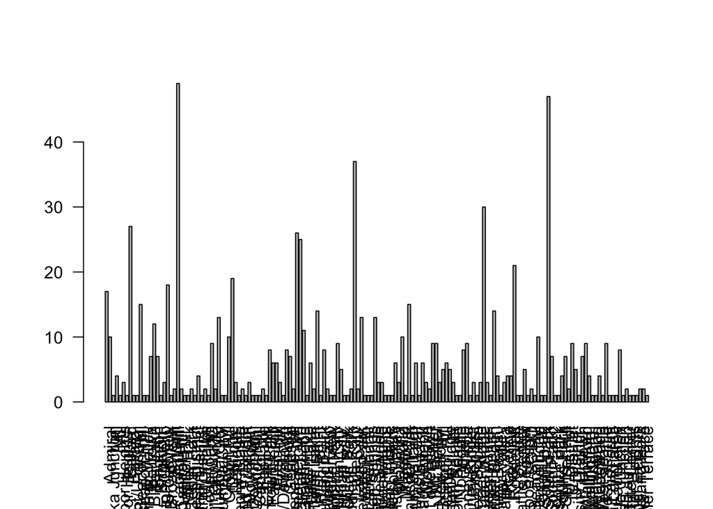

```r
barplot(table(var),las=2)
```

The bar plot is very hard to look at because of the large number of values. There are 160 levels in this factor variable. Perhaps I will look at the Council District which covers a larger area.

```r
var=data$Council.District.
getMode(var)
```

```
## [1] "1"
```

```r
prop.table(table(data$Council.District.))
```

```
##
##          1          2          3          4          5          6
## 0.23798627 0.20022883 0.12013730 0.10411899 0.13958810 0.10869565
##          7
## 0.08924485
```

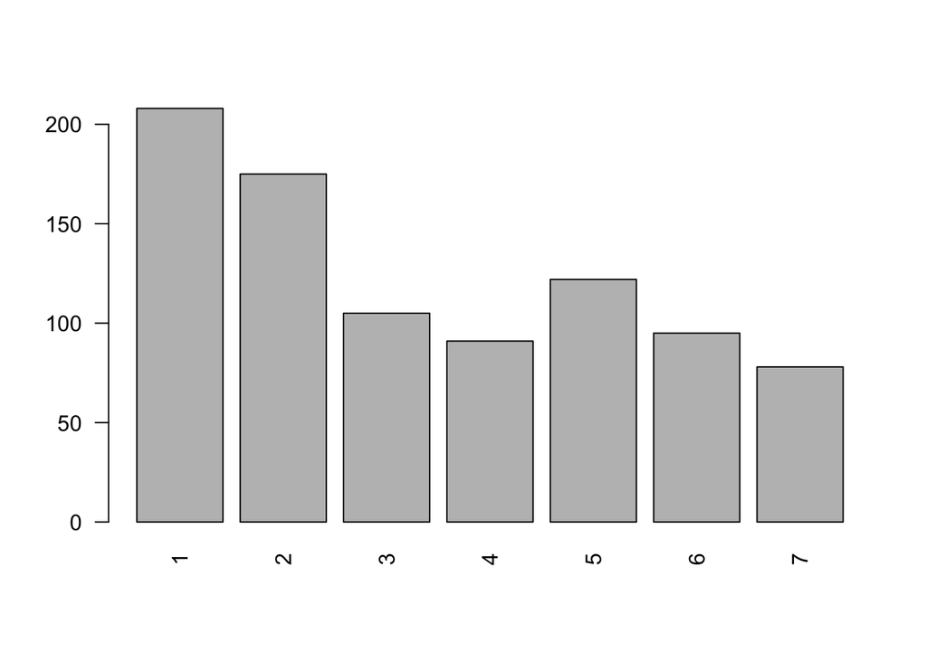

```r
barplot(table(var), las=2)
```

Just looking at the raw data, the variable “Project Type” looks like it might have been populated by the data owner, not the applicant, since the values look consistent. So, I want to know if there was a more common type of budget proposed.

```r
var=data$Project.Type
prop.table(table(data$Project.Type))
```

```
##
##                              Accessibility Improvements
##                 0.089244851                 0.051487414
##       Crossing Improvements        Green Infrastructure
##                 0.321510297                 0.025171625
##                    Lighting            Low-cost Curbing
##                 0.029748284                 0.003432494
##                       Other              Park Equipment
##                 0.074370709                 0.098398169
## Place-making/Beautification               School Safety
##                 0.035469108                 0.006864989
##                     Signage             Traffic-calming
##                 0.040045767                 0.001144165
##             Traffic-Calming                    Walkways
##                 0.115560641                 0.107551487
```

It looks like “Crossing Improvements” may have the highest frequency. Confirming with the getMode function.

```r
getMode(var)
```

```
## [1] "Crossing Improvements"
```

I’m curious if there is any relationship between Project Type and Project status. So, I’ll look at a contingency table.

```r
table(data$Project.Status, data$Project.Type)
```

```
##
##                                      Accessibility Improvements
##   Already Funded                   2                          4
##   Did Not Advance                 12                         23
##   Funded for 2018 Implementation   4                          4
##   Not Feasible                    51                          7
##   On Ballot, Not Funded            0                          7
##   Referred to Maintenance          9                          0
##
##                                  Crossing Improvements
##   Already Funded                                    39
##   Did Not Advance                                  171
##   Funded for 2018 Implementation                    28
##   Not Feasible                                      30
##   On Ballot, Not Funded                             13
##   Referred to Maintenance                            0
##
##                                  Green Infrastructure Lighting
##   Already Funded                                    0        2
##   Did Not Advance                                  17       15
##   Funded for 2018 Implementation                    0        2
##   Not Feasible                                      3        7
##   On Ballot, Not Funded                             0        0
##   Referred to Maintenance                           2        0
##
##                                  Low-cost Curbing Other Park Equipment
##   Already Funded                                0     0              0
##   Did Not Advance                               3    25             47
##   Funded for 2018 Implementation                0     1              0
##   Not Feasible                                  0    37             37
##   On Ballot, Not Funded                         0     0              1
##   Referred to Maintenance                       0     2              1
##
##                                  Place-making/Beautification School Safety
##   Already Funded                                           0             0
##   Did Not Advance                                          7             3
##   Funded for 2018 Implementation                           1             0
##   Not Feasible                                            22             2
##   On Ballot, Not Funded                                    1             1
##   Referred to Maintenance                                  0             0
##
##                                  Signage Traffic-calming Traffic-Calming
##   Already Funded                       0               0               3
##   Did Not Advance                     28               1              84
##   Funded for 2018 Implementation       0               0               2
##   Not Feasible                         5               0               8
##   On Ballot, Not Funded                1               0               4
##   Referred to Maintenance              1               0               0
##
##                                  Walkways
##   Already Funded                        0
##   Did Not Advance                      66
##   Funded for 2018 Implementation        5
##   Not Feasible                         15
##   On Ballot, Not Funded                 7
##   Referred to Maintenance               1
```

```r
table(data$Project.Type, data$Project.Status)
```

```
##
##                               Already Funded Did Not Advance
##                                            2              12
##   Accessibility Improvements               4              23
##   Crossing Improvements                   39             171
##   Green Infrastructure                     0              17
##   Lighting                                 2              15
##   Low-cost Curbing                         0               3
##   Other                                    0              25
##   Park Equipment                           0              47
##   Place-making/Beautification              0               7
##   School Safety                            0               3
##   Signage                                  0              28
##   Traffic-calming                          0               1
##   Traffic-Calming                          3              84
##   Walkways                                 0              66
##
##                               Funded for 2018 Implementation Not Feasible
##                                                            4           51
##   Accessibility Improvements                               4            7
##   Crossing Improvements                                   28           30
##   Green Infrastructure                                     0            3
##   Lighting                                                 2            7
##   Low-cost Curbing                                         0            0
##   Other                                                    1           37
##   Park Equipment                                           0           37
##   Place-making/Beautification                              1           22
##   School Safety                                            0            2
##   Signage                                                  0            5
##   Traffic-calming                                          0            0
##   Traffic-Calming                                          2            8
##   Walkways                                                 5           15
##
##                               On Ballot, Not Funded
##                                                   0
##   Accessibility Improvements                      7
##   Crossing Improvements                          13
##   Green Infrastructure                            0
##   Lighting                                        0
##   Low-cost Curbing                                0
```

[output cut: 9 more lines]

```
##                               Referred to Maintenance
##                                                     9
##   Accessibility Improvements                        0
##   Crossing Improvements                             0
##   Green Infrastructure                              2
##   Lighting                                          0
##   Low-cost Curbing                                  0
##   Other                                             2
##   Park Equipment                                    1
##   Place-making/Beautification                       0
##   School Safety                                     0
##   Signage                                           1
##   Traffic-calming                                   0
##   Traffic-Calming                                   0
##   Walkways                                          1
```

The second crosstab looks a little more reasonable. I’ll continue exploring this.

```r
library(gmodels)
CrossTable(data$Project.Type,data$Project.Status,prop.t=F, prop.r=F, prop.c=F,prop.chisq=F)
```

```
##
##
##    Cell Contents
## |-------------------------|
## |                       N |
## |-------------------------|
##
##
## Total Observations in Table:  874
##
##
##                             | data$Project.Status
##           data$Project.Type |                 Already Funded |                Did Not Advance | Funded for 2018 Implementation |                   Not Feasible |          On Ballot, Not Funded |        Referred to Maintenance |                      Row Total |
## ----------------------------|--------------------------------|--------------------------------|--------------------------------|--------------------------------|--------------------------------|--------------------------------|--------------------------------|
##                             |                              2 |                             12 |                              4 |                             51 |                              0 |                              9 |                             78 |
## ----------------------------|--------------------------------|--------------------------------|--------------------------------|--------------------------------|--------------------------------|--------------------------------|--------------------------------|
##  Accessibility Improvements |                              4 |                             23 |                              4 |                              7 |                              7 |                              0 |                             45 |
## ----------------------------|--------------------------------|--------------------------------|--------------------------------|--------------------------------|--------------------------------|--------------------------------|--------------------------------|
##       Crossing Improvements |                             39 |                            171 |                             28 |                             30 |                             13 |                              0 |                            281 |
## ----------------------------|--------------------------------|--------------------------------|--------------------------------|--------------------------------|--------------------------------|--------------------------------|--------------------------------|
##        Green Infrastructure |                              0 |                             17 |                              0 |                              3 |                              0 |                              2 |                             22 |
## ----------------------------|--------------------------------|--------------------------------|--------------------------------|--------------------------------|--------------------------------|--------------------------------|--------------------------------|
##                    Lighting |                              2 |                             15 |                              2 |                              7 |                              0 |                              0 |                             26 |
## ----------------------------|--------------------------------|--------------------------------|--------------------------------|--------------------------------|--------------------------------|--------------------------------|--------------------------------|
##            Low-cost Curbing |                              0 |                              3 |                              0 |                              0 |                              0 |                              0 |                              3 |
## ----------------------------|--------------------------------|--------------------------------|--------------------------------|--------------------------------|--------------------------------|--------------------------------|--------------------------------|
##                       Other |                              0 |                             25 |                              1 |                             37 |                              0 |                              2 |                             65 |
## ----------------------------|--------------------------------|--------------------------------|--------------------------------|--------------------------------|--------------------------------|--------------------------------|--------------------------------|
##              Park Equipment |                              0 |                             47 |                              0 |                             37 |                              1 |                              1 |                             86 |
## ----------------------------|--------------------------------|--------------------------------|--------------------------------|--------------------------------|--------------------------------|--------------------------------|--------------------------------|
```

[output cut: 16 more lines]

It looks like there might be some observations without anything in the “Project Type” field. So, I’ll need to clean this column of data as well. Trying a table:

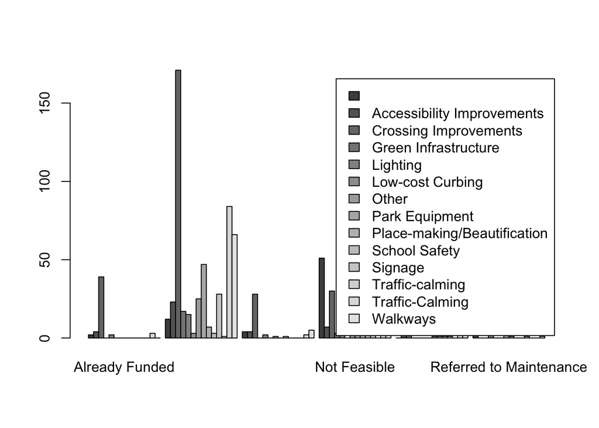

```r
legendPlot=levels(as.factor(unique(data$Project.Type)))
bartable = table(data$Project.Type,data$Project.Status)
barplot(bartable, beside = TRUE,legend=legendPlot)
```

I’m going to have to figure out how to reposition the legend! I also tried the following:

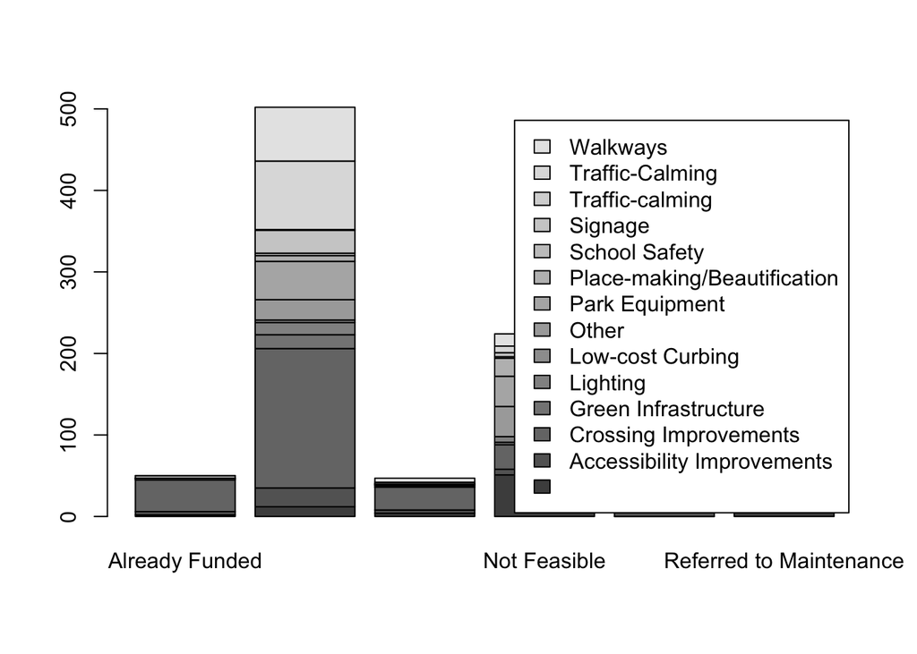

```r
legendPlot=levels(as.factor(unique(data$Project.Type)))
bartable = table(data$Project.Type,data$Project.Status)
barplot(bartable, legend=legendPlot)
```